# AMCAT Data Analysis IN1241112

### Importing Required Libraries

```python
import pandas as pd
import numpy as np
import fuzzywuzzy
from fuzzywuzzy import process
import matplotlib.pyplot as plt
from scipy.stats import chi2_contingency
from scipy import stats
import seaborn as sns
```

### Loading Dataset

```python
df = pd.read_excel(r"C:\Users\91832\Downloads\data (1).xlsx")
```

```python
df.head() # first 5 rows x columns data
```

|  | Unnamed: 0 | ID | Salary | DOJ | DOL | Designation | JobCity | Gender | DOB | 10percentage | ... | ComputerScience | MechanicalEngg | ElectricalEngg | TelecomEngg | CivilEngg | conscientiousness | agreeableness | extraversion | nueroticism | openess_to_experience |
| --- | --- | --- | --- | --- | --- | --- | --- | --- | --- | --- | --- | --- | --- | --- | --- | --- | --- | --- | --- | --- | --- |
| 0 | train | 203097 | 420000 | 2012-06-01 | present | senior quality engineer | Bangalore | f | 1990-02-19 | 84.3 | ... | -1 | -1 | -1 | -1 | -1 | 0.9737 | 0.8128 | 0.5269 | 1.35490 | -0.4455 |
| 1 | train | 579905 | 500000 | 2013-09-01 | present | assistant manager | Indore | m | 1989-10-04 | 85.4 | ... | -1 | -1 | -1 | -1 | -1 | -0.7335 | 0.3789 | 1.2396 | -0.10760 | 0.8637 |
| 2 | train | 810601 | 325000 | 2014-06-01 | present | systems engineer | Chennai | f | 1992-08-03 | 85.0 | ... | -1 | -1 | -1 | -1 | -1 | 0.2718 | 1.7109 | 0.1637 | -0.86820 | 0.6721 |
| 3 | train | 267447 | 1100000 | 2011-07-01 | present | senior software engineer | Gurgaon | m | 1989-12-05 | 85.6 | ... | -1 | -1 | -1 | -1 | -1 | 0.0464 | 0.3448 | -0.3440 | -0.40780 | -0.9194 |
| 4 | train | 343523 | 200000 | 2014-03-01 | 2015-03-01 00:00:00 | get | Manesar | m | 1991-02-27 | 78.0 | ... | -1 | -1 | -1 | -1 | -1 | -0.8810 | -0.2793 | -1.0697 | 0.09163 | -0.1295 |

5 rows × 39 columns

```python
df.info() # inoformation of the data uncleaned
```

```
<class 'pandas.core.frame.DataFrame'>
RangeIndex: 3998 entries, 0 to 3997
Data columns (total 39 columns):
 #   Column                 Non-Null Count  Dtype
---  ------                 --------------  -----
 0   Unnamed: 0             3998 non-null   object
 1   ID                     3998 non-null   int64
 2   Salary                 3998 non-null   int64
 3   DOJ                    3998 non-null   datetime64[ns]
 4   DOL                    3998 non-null   object
 5   Designation            3998 non-null   object
 6   JobCity                3998 non-null   object
 7   Gender                 3998 non-null   object
 8   DOB                    3998 non-null   datetime64[ns]
 9   10percentage           3998 non-null   float64
```

[output cut: 31 more lines]

```python
df.describe() # analysis of unlceaned data
```

|  | ID | Salary | DOJ | DOB | 10percentage | 12graduation | 12percentage | CollegeID | CollegeTier | collegeGPA | ... | ComputerScience | MechanicalEngg | ElectricalEngg | TelecomEngg | CivilEngg | conscientiousness | agreeableness | extraversion | nueroticism | openess_to_experience |
| --- | --- | --- | --- | --- | --- | --- | --- | --- | --- | --- | --- | --- | --- | --- | --- | --- | --- | --- | --- | --- | --- |
| count | 3.998000e+03 | 3.998000e+03 | 3998 | 3998 | 3998.000000 | 3998.000000 | 3998.000000 | 3998.000000 | 3998.000000 | 3998.000000 | ... | 3998.000000 | 3998.000000 | 3998.000000 | 3998.000000 | 3998.000000 | 3998.000000 | 3998.000000 | 3998.000000 | 3998.000000 | 3998.000000 |
| mean | 6.637945e+05 | 3.076998e+05 | 2013-07-02 11:04:10.325162496 | 1990-12-06 06:01:15.637819008 | 77.925443 | 2008.087544 | 74.466366 | 5156.851426 | 1.925713 | 71.486171 | ... | 90.742371 | 22.974737 | 16.478739 | 31.851176 | 2.683842 | -0.037831 | 0.146496 | 0.002763 | -0.169033 | -0.138110 |
| min | 1.124400e+04 | 3.500000e+04 | 1991-06-01 00:00:00 | 1977-10-30 00:00:00 | 43.000000 | 1995.000000 | 40.000000 | 2.000000 | 1.000000 | 6.450000 | ... | -1.000000 | -1.000000 | -1.000000 | -1.000000 | -1.000000 | -4.126700 | -5.781600 | -4.600900 | -2.643000 | -7.375700 |
| 25% | 3.342842e+05 | 1.800000e+05 | 2012-10-01 00:00:00 | 1989-11-16 06:00:00 | 71.680000 | 2007.000000 | 66.000000 | 494.000000 | 2.000000 | 66.407500 | ... | -1.000000 | -1.000000 | -1.000000 | -1.000000 | -1.000000 | -0.713525 | -0.287100 | -0.604800 | -0.868200 | -0.669200 |
| 50% | 6.396000e+05 | 3.000000e+05 | 2013-11-01 00:00:00 | 1991-03-07 12:00:00 | 79.150000 | 2008.000000 | 74.400000 | 3879.000000 | 2.000000 | 71.720000 | ... | -1.000000 | -1.000000 | -1.000000 | -1.000000 | -1.000000 | 0.046400 | 0.212400 | 0.091400 | -0.234400 | -0.094300 |
| 75% | 9.904800e+05 | 3.700000e+05 | 2014-07-01 00:00:00 | 1992-03-13 18:00:00 | 85.670000 | 2009.000000 | 82.600000 | 8818.000000 | 2.000000 | 76.327500 | ... | -1.000000 | -1.000000 | -1.000000 | -1.000000 | -1.000000 | 0.702700 | 0.812800 | 0.672000 | 0.526200 | 0.502400 |
| max | 1.298275e+06 | 4.000000e+06 | 2015-12-01 00:00:00 | 1997-05-27 00:00:00 | 97.760000 | 2013.000000 | 98.700000 | 18409.000000 | 2.000000 | 99.930000 | ... | 715.000000 | 623.000000 | 676.000000 | 548.000000 | 516.000000 | 1.995300 | 1.904800 | 2.535400 | 3.352500 | 1.822400 |
| std | 3.632182e+05 | 2.127375e+05 | NaN | NaN | 9.850162 | 1.653599 | 10.999933 | 4802.261482 | 0.262270 | 8.167338 | ... | 175.273083 | 98.123311 | 87.585634 | 104.852845 | 36.658505 | 1.028666 | 0.941782 | 0.951471 | 1.007580 | 1.008075 |

8 rows × 29 columns

```python
df.describe(include='object')
```

|  | Unnamed: 0 | DOL | Designation | JobCity | Gender | 10board | 12board | Degree | Specialization | CollegeState |
| --- | --- | --- | --- | --- | --- | --- | --- | --- | --- | --- |
| count | 3998 | 3998 | 3998 | 3998 | 3998 | 3998 | 3998 | 3998 | 3998 | 3998 |
| unique | 1 | 67 | 419 | 339 | 2 | 275 | 340 | 4 | 46 | 26 |
| top | train | present | software engineer | Bangalore | m | cbse | cbse | B.Tech/B.E. | electronics and communication engineering | Uttar Pradesh |
| freq | 3998 | 1875 | 539 | 627 | 3041 | 1395 | 1400 | 3700 | 880 | 915 |

## Data Cleaning

```python
# Duplicates
df.duplicated().sum()
```

```
0
```

### Dropping columns and Rows

```python
df = df.drop(['Unnamed: 0'], axis = 1)
```

```python
df['JobCity'] = df['JobCity'].str.upper()
df['JobCity'] = df['JobCity'].str.strip()
```

```python
# using FuzzyWuzzy to Correct the Words
choices = ['BANGALORE',"INDORE","CHENNAI",'GURGAON', 'HYDERABAD','NOIDA', 'KOLKATA', 'PUNE','MOHALI', 'JHANSI','NEW DELHI',
               'BHUBANESWAR', 'MUMBAI', 'MANGALORE', 'REWARI', 'GHAZIABAD','BHIWADI','MYSORE', 'RAJKOT', 'JAIPUR', 'THANE',
              'MAHARAJGANJ','THIRUVANANTHAPURAM','PANCHKULA','COIMBATORE', 'DHANBAD', 'LUCKNOW', 'GANDHI NAGAR',
           'DAMAN AND DIU', 'NAGPUR', 'BHAGALPUR','AHMEDABAD', 'KOCHI', 'BANKURA', 'KANPUR', 'VIJAYAWADA', 'BEAWAR', 'ALWAR',
           'SILIGURI', 'RAIPUR', 'BHOPAL', 'JODHPUR', 'UDAIPUR','MUZAFFARPUR', 'BULANDSHAHAR', 'HARIDWAR', 'RAIGARH','VISAKHAPATNAM',
            'JABALPUR', 'UNNAO', 'FARIDABAD', 'AURANGABAD','BELGAUM', 'DEHRADUN', 'RUDRAPUR', 'JAMSHEDPUR','DHARAMSHALA','HISSAR', 'RANCHI',
    'MADURAI','CHANDIGARH', 'AUSTRALIA', 'CHEYYAR', 'SONEPAT',
           'PANTNAGAR', 'JAGDALPUR', 'ANGUL', 'BARODA',
           'ARIYALUR', 'JOWAI',
           'NEEMRANA', 'TIRUPATI',
           'DUBAI', 'AHMEDNAGAR', 'NASHIK', 'BALLARI', 'LUDHIANA',
           'MUZAFFARNAGAR', 'GAGRET','GWALIOR',
           'SONIPAT', 'BAREILLY', 'HOSPET',
           'MIRYALAGUDA', 'DHARUHERA', 'MEERUT', 'GANJAM', 'HUBLI', 'NCR',
           'AGRA', 'TRICHY', 'KUDANKULAM ,TARAPUR', 'ONGOLE', 'SAMBALPUR',
           'PONDICHERRY', 'BUNDI', 'SADULPUR',
           'BIKANER', 'VADODARA', 'ASANSOL', 'TIRUNELVELI',
           'ERNAKULAM', 'BILASPUR', 'CHANDRAPUR', 'NANDED', 'DHARMAPURI',
           'VANDAVASI', 'ROHTAK', 'PATNA', 'SALEM',
           'BHARUCH', 'TORNAGALLU', 'JASPUR',
           'BURDWAN', 'SHIMLA','JAMMU', 'SHAHDOL',
           'MUVATTUPUZHA', 'AL JUBAIL', 'KALMAR',
           'SECUNDERABAD', 'RATNAGIRI', 'JHAJJAR',
           'GULBARGA', 'NALAGARH',
           'JEDDAH', 'JAMNAGAR',
           'GONDA', 'ORISSA',
           'JOSHIMATH', 'BATHINDA', 'JOHANNESBURG', 'KALA AMB', 'KARNAL',
           'LONDON', 'KOTA', 'BADDI', 'NAGARI',
           'METTUR', 'DURGAPUR', 'PONDI', 'SURAT', 'KURNOOL',
           'KOLHAPUR', 'BHILAI', 'BAHADURGARH',
           'RAYAGADA', 'KAKINADA', 'VARANASI', 'NELLORE',
           'HOWRAH', 'TRICHUR', 'AMBALA', 'KHOPOLI', 'ROORKEE',
           'ALLAHABAD', 'JALANDHAR', 'MANESAR', 'VAPI', 'PILANI',
           'RAS AL KHAIMAH', 'SINGARULI',
           'PHAGWARA', 'BARIPADA', 'YAMUNA NAGAR', 'SHAHIBABAD',
           'SAMPLA', 'GUWAHATI', 'ROURKELA', 'VELLORE', 'DAUSA',
           'LATUR', 'MAINPURI', 'DAMMAM', 'HALDIA',
           'RAE BARELI', 'PATIALA', 'GORAKHPUR', 'AMBALA CITY',
           'KARAD', 'RAJPURA']
```

```python
def correct_spelling (target_word="", choices=[], threshold=80):
    match, score = process.extractOne(target_word, choices)
    if score >= threshold:
        return match
    else:
        return target_word
```

```python
df['JobCity'] = df['JobCity'].apply(lambda i : correct_spelling(str(i), choices))
```

```python
df["JobCity"] = df["JobCity"].replace("BENGALURU","BANGALORE", regex = False)
```

```python
choice = [
           'electronics and communication engineering',
           'information technology', 'computer science and engineering',
           'mechanical engineering', 'electronics and electrical engineering',
           'electronics & telecommunications',
           'instrumentation and control engineering', 'computer application',
           'electronics and computer engineering', 'electrical engineering',
           'applied electronics and instrumentation',
           'information science engineering', 'civil engineering',
           'mechanical and automation', 'industrial & production engineering',
           'control and instrumentation engineering',
           'metallurgical engineering',
           'electronics and instrumentation engineering',
           'electronics engineering', 'ceramic engineering',
           'chemical engineering', 'aeronautical engineering', 'other',
           'biotechnology', 'embedded systems technology',
           'electrical and power engineering',
           'computer science and technology', 'mechatronics',
           'automobile/automotive engineering', 'polymer technology',
           'mechanical & production engineering',
           'power systems and automation', 'instrumentation engineering',
           'telecommunication engineering',
           'industrial & management engineering', 'industrial engineering',
           'computer and communication engineering',
           'information & communication technology',
           'internal combustion engine', 'computer networking',
           'biomedical engineering']
```

```python
  def correct_spelling(target_word="", choice=[], threshold=80):
        match, score = process.extractOne(target_word, choices)
        if score >= threshold:
            return match
        else:
            return target_word
```

```python
df['Specialization'] = df['Specialization'].apply(lambda i : correct_spelling_errors(str(i), choices))
```

```python
# using date and time func to manipulate the time data
df['DOL'] = df['DOL'].replace('present', "2015-12-31" )
```

```python
df['DOL'] = df['DOL'].astype('datetime64[ns]')
```

```python
df["Total_Exp"] = df['DOL'].dt.year - df['DOJ'].dt.year
```

```python
df["Age"] = 2015 - df['DOB'].dt.year
```

```python
df["Age"] = 2015 - df['DOB'].dt.year
```

```python
df.drop(dd[dd['Total_Exp'] == 24].index, inplace = True)
```

```python
df.drop(['DOB','DOJ','DOL'], axis = 1, inplace = True )
```

#### Typecasting

```python
df.columns
```

[output not shown]

```python
df.dtypes
```

[output not shown]

```python
df['Salary'] = df['Salary'].astype('int32')
df['CollegeTier'] = df['CollegeTier'].astype('int8')
df['collegeGPA'] = df['collegeGPA'].astype('float16')
df['Domain'] = df['Domain'].astype('float16')
df['ComputerProgramming'] = df['ComputerProgramming'].astype('int16')
df['ElectronicsAndSemicon'] = df['ElectronicsAndSemicon'].astype('int16')
df['ComputerScience'] = df['ComputerScience'].astype('int16')
df['MechanicalEngg'] = df['MechanicalEngg'].astype('int16')
df['ElectricalEngg'] = df['ElectricalEngg'].astype('int16')
df['TelecomEngg'] = df['TelecomEngg'].astype('int16')
df['CivilEngg'] = df['CivilEngg'].astype('int16')
df['conscientiousness'] = df['conscientiousness'].astype('float16')
df['agreeableness'] = df['agreeableness'].astype('float16')
df['extraversion'] = df['extraversion'].astype('float16')
df['nueroticism'] = df['nueroticism'].astype('float16')
df['openess_to_experience'] = df['openess_to_experience'].astype('float16')
df['GraduationYear'] = df['GraduationYear'].astype('int16')
df['English'] = df['English'].astype('int16')
df['Logical'] = df['Logical'].astype('int16')
df['Quant'] = df['Quant'].astype('int16')
```

```python
df.info()
```

[output not shown]

[output cut: 30 more lines]

## Data Analysis

### Univariate Analysis

```python
object_col = df.select_dtypes(include=['object'])

numerical_col = df.select_dtypes(exclude=['object'])

object_col.columns
```

```
Index(['DOL', 'Designation', 'JobCity', 'Gender', '10board', '12board',
       'Degree', 'Specialization', 'CollegeState'],
      dtype='object')
```

```python
top_roles = df['Designation'].value_counts().head(10)
bottom_roles = df['Designation'].value_counts().tail(10)
```

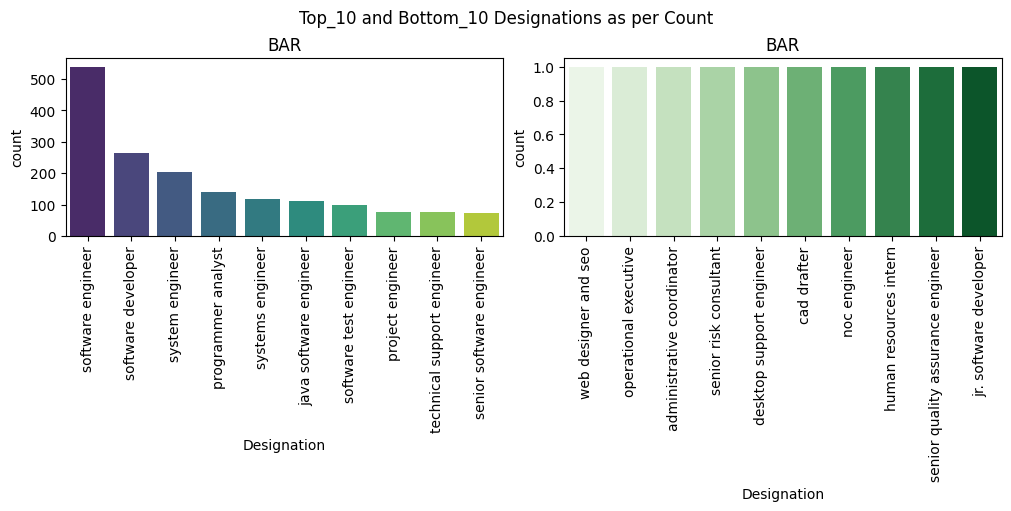

```python
fig, axs = plt.subplots(1, 2, figsize=(10, 5), constrained_layout=True)
fig.suptitle("Top_10 and Bottom_10 Designations as per Count")

axs[0].set_title("BAR")
sns.countplot(data=df, x='Designation', order=top_roles.index , palette='viridis', ax=axs[0])
axs[0].tick_params(axis='x', rotation=90)

axs[1].set_title("BAR")
sns.countplot(data=df, x='Designation', order=bottom_roles.index ,palette='Greens', ax=axs[1])
axs[1].tick_params(axis='x', rotation=90)

plt.show()
```

```python
top_city = df['JobCity'].value_counts().head(10)
bottom_city = df['JobCity'].value_counts().tail(10)
```

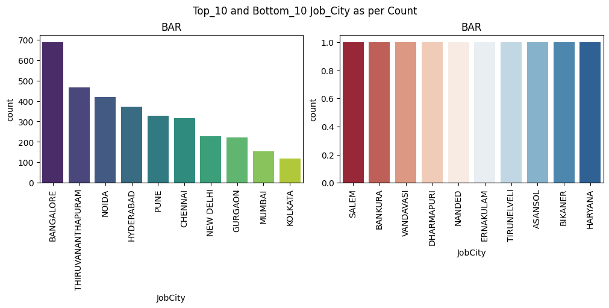

```python
fig, axs = plt.subplots(1, 2, figsize=(10, 5), constrained_layout=True)
fig.suptitle("Top_10 and Bottom_10 Job_City as per Count")

axs[0].set_title("BAR")
sns.countplot(data=df, x='JobCity', order=top_city.index , palette='viridis', ax=axs[0])
axs[0].tick_params(axis='x', rotation=90)

axs[1].set_title("BAR")
sns.countplot(data=df, x='JobCity', order=bottom_city.index ,palette='RdBu', ax=axs[1])
axs[1].tick_params(axis='x', rotation=90)

plt.show()
```

### Conclusion

**even though Tier 1 cities have Domination among top 10 Job_Cities, 3 Tier_2 cities has the gross combination of 34% among top_10**

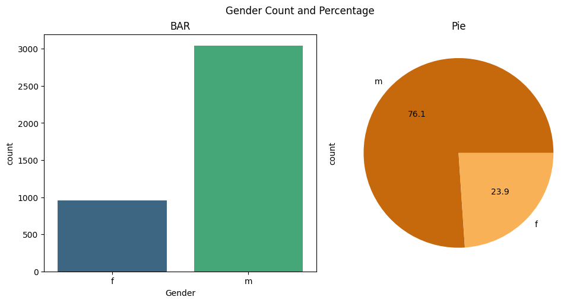

```python
fig, axs = plt.subplots(1, 2, figsize=(10, 5), constrained_layout=True)
fig.suptitle("Gender Count and Percentage")

axs[0].set_title("BAR")
sns.countplot(data=df, x='Gender',palette='viridis', ax=axs[0])

axs[1].set_title("Pie")
colors = sns.color_palette('PuOr')
df['Gender'].value_counts().plot(kind = 'pie', autopct = '%1.1f', colors = colors,ax=axs[1])

plt.show()
```

### Conclusion

**candidates from Gender male are recorded to be 3 times more of Female candidates**

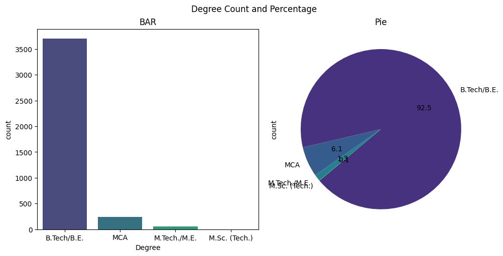

```python
fig, axs = plt.subplots(1, 2, figsize=(10, 5), constrained_layout=True)
fig.suptitle("Degree Count and Percentage")

axs[0].set_title("BAR")
sns.countplot(data=df, x='Degree',palette='viridis', ax=axs[0] , )

axs[1].set_title("Pie")
colors = sns.color_palette('viridis')
df['Degree'].value_counts().plot(kind = 'pie', autopct = '%1.1f', colors = colors,ax=axs[1] , startangle=220)

plt.show()
```

### Conclusion

**from the record it is clear that B.Tech/B.E. has the upper hand /Domination than other degrees with masive Numbers of above 90%,that has huge margin between all other degrees combine, with less than 10%**

```python
top_sp = df['Specialization'].value_counts().head(10)
bottom_sp = df['Specialization'].value_counts().tail(10)
```

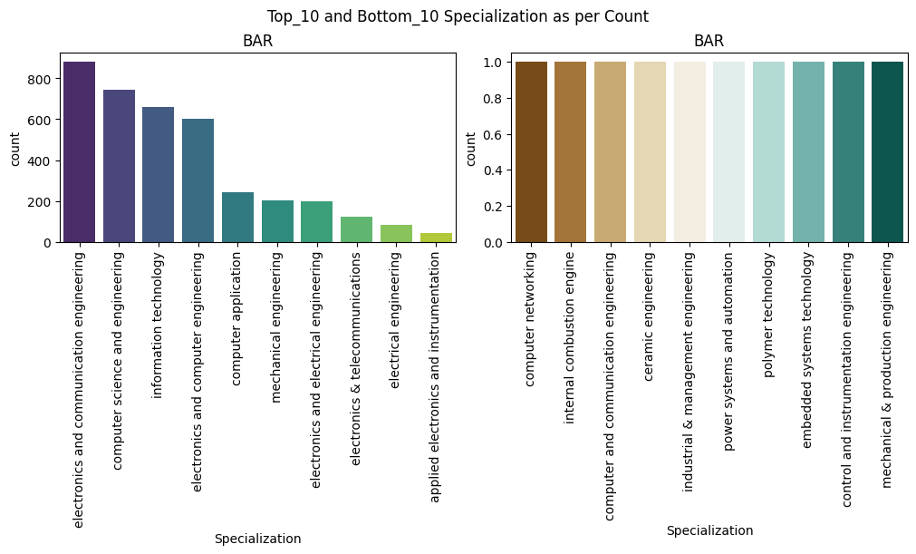

```python
fig, axs = plt.subplots(1, 2, figsize=(10, 6), constrained_layout=True)
fig.suptitle("Top_10 and Bottom_10 Specialization as per Count")

axs[0].set_title("BAR")
sns.countplot(data=df, x='Specialization', order=top_sp.index , palette='viridis', ax=axs[0])
axs[0].tick_params(axis='x', rotation=90)

axs[1].set_title("BAR")
sns.countplot(data=df, x='Specialization', order=bottom_sp.index ,palette='BrBG', ax=axs[1])
axs[1].tick_params(axis='x', rotation=90)

plt.show()
```

### Conclusion

**by observing the above Designations it seems that "software engineer" has been on top, though the dominated number of candidates are from electronics engineering Specializtion .**

**Which tells us that people who chose to change their domains has got skills more than that od other IT domains and working as the "software engineer"**

```python
top_clg = df['CollegeState'].value_counts().head(14)
bottom_clg = df['CollegeState'].value_counts().tail(12)
```

[figure not shown]

```python
fig, axs = plt.subplots(1, 2, figsize=(12, 5), constrained_layout=True)
fig.suptitle("Top_10 and Bottom_10 College_State as per Count")

axs[0].set_title("BAR")
sns.countplot(data=df, x='CollegeState', order=top_clg.index , palette='viridis', ax=axs[0])
axs[0].tick_params(axis='x', rotation=90)

axs[1].set_title("BAR")
sns.countplot(data=df, x='CollegeState', order=bottom_clg.index ,palette='Blues', ax=axs[1])
axs[1].tick_params(axis='x', rotation=90)

plt.show()
```

### conclusion

**Approximately 50% of candidates have done their graduation from 4 states, with 1/4th of total candidates from Uttarpradesh.**

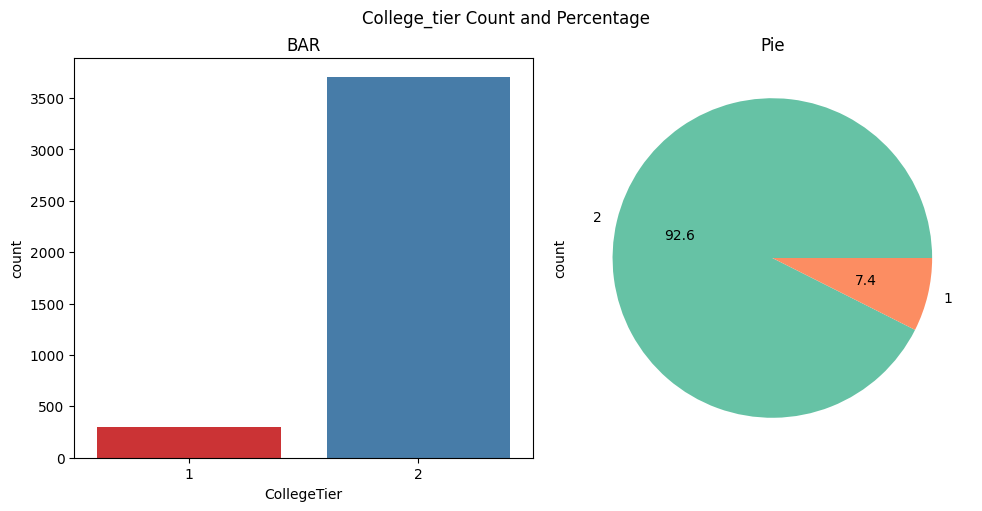

```python
fig, axs = plt.subplots(1, 2, figsize=(10, 5), constrained_layout=True)
fig.suptitle("College_tier Count and Percentage")

axs[0].set_title("BAR")
sns.countplot(data=df, x='CollegeTier',palette='Set1', ax=axs[0])

axs[1].set_title("Pie")
colors = sns.color_palette('Set2')
df['CollegeTier'].value_counts().plot(kind = 'pie', autopct = '%1.1f', colors = colors,ax=axs[1])


plt.show()
```

### Conclusion

**Candidates from tier_2 colleges are more interested in AMCAT, Candidates from Tier_2 are 13 times more in number than Tier_1.**

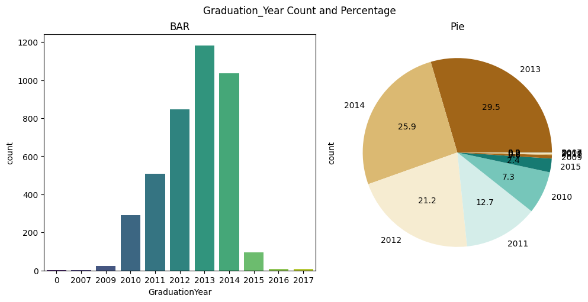

```python
fig, axs = plt.subplots(1, 2, figsize=(10, 5), constrained_layout=True)
fig.suptitle("Graduation_Year Count and Percentage")

axs[0].set_title("BAR")
sns.countplot(data=df, x='GraduationYear',palette='viridis', ax=axs[0])

axs[1].set_title("Pie")
colors = sns.color_palette('BrBG')
df['GraduationYear'].value_counts().plot(kind = 'pie', autopct = '%1.1f', colors = colors,ax=axs[1])
```

### Conclusion

**As the data is from 2015, most of the candidates are recent graduates, candidates who completed graduation in years 2012,2013 and 2014 combine are 3 times that of candidates who completed graduation in other years. 2016 and 2017 are candidates who are yet to complete their graduation.**

```python
 sns.set(style="darkgrid", palette="RdBu")
```

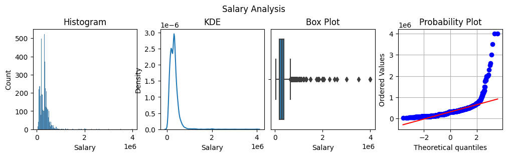

```python
fig, axs = plt.subplots(1, 4, figsize=(10, 3), constrained_layout=True)
fig.suptitle("Salary Analysis")

axs[0].set_title("Histogram")
sns.histplot(data=df, x='Salary', ax=axs[0])

axs[1].set_title("KDE")
sns.kdeplot(data=df, x='Salary', ax=axs[1])

axs[2].set_title("Box Plot")
sns.boxplot(data=df, x='Salary', ax=axs[2])

stats.probplot(df['Salary'], dist=stats.norm, plot=axs[3])
axs[3].grid()
plt.show()
```

### Conclusion

**As salary is True data outliers are retained. Salary is not normally distributed, it is right skewed, which tell that there are candidates earning high income per annum.**

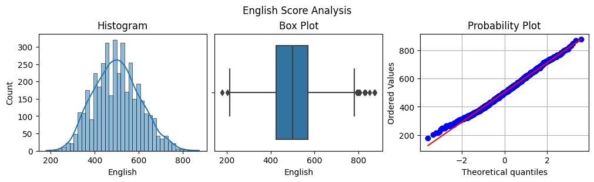

```python
    fig, axs = plt.subplots(1, 3, figsize=(10, 3), constrained_layout=True)
    fig.suptitle("English Score Analysis")

    axs[0].set_title("Histogram")
    sns.histplot(data=df, x='English', kde = True, ax=axs[0])

    axs[1].set_title("Box Plot")
    sns.boxplot(data=df, x='English', ax=axs[1])

    stats.probplot(df['English'], dist=stats.norm, plot=axs[2])
    axs[2].grid()

    plt.show()
```

### Conclusion

**Although there are few ouliers, English scores are normally distribuited with maximum candidates lying inside the whisker**

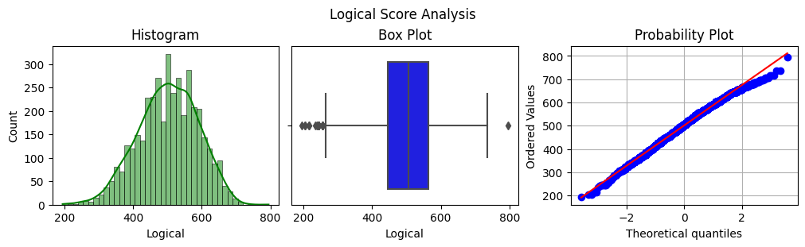

```python
    fig, axs = plt.subplots(1, 3, figsize=(10, 3), constrained_layout=True)
    fig.suptitle("Logical Score Analysis")

    axs[0].set_title("Histogram")
    sns.histplot(data=df, x='Logical', kde = True, ax=axs[0], color = 'green')

    axs[1].set_title("Box Plot")
    sns.boxplot(data=df, x='Logical', ax=axs[1], color = 'blue')

    stats.probplot(df['Logical'], dist=stats.norm, plot=axs[2])
    axs[2].grid()

    plt.show()
```

### conclusion

**Most of the candidates have scored marks between 250 and 700 making this a normal distributed data.**

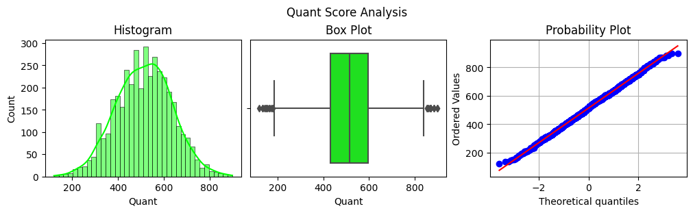

```python
    fig, axs = plt.subplots(1, 3, figsize=(10, 3), constrained_layout=True)
    fig.suptitle("Quant Score Analysis")

    axs[0].set_title("Histogram")
    sns.histplot(data=df, x='Quant', kde = True, ax=axs[0], color = 'lime')

    axs[1].set_title("Box Plot")
    sns.boxplot(data=df, x='Quant', ax=axs[1], color = 'lime')

    stats.probplot(df['Quant'], dist=stats.norm, plot=axs[2])
    axs[2].grid()

    plt.show()
```

### Conclusion

**Its a perfect normal distribution.**

```python
cp = df[df['ComputerProgramming'] != -1]
```

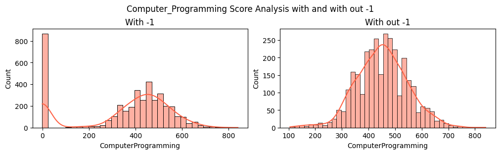

```python
    fig, axs = plt.subplots(1, 2, figsize=(10, 3), constrained_layout=True)
    fig.suptitle("Computer_Programming Score Analysis with and with out -1")

    axs[0].set_title("With -1")
    sns.histplot(data=df, x='ComputerProgramming', kde = True, ax=axs[0], color = 'tomato')

    axs[1].set_title("With out -1")
    sns.histplot(data=cp, x='ComputerProgramming', kde = True, ax=axs[1], color = 'tomato')

    plt.show()
```

### Consluion

**Computer programming is one of optional subjects, -1 represents candidates have not choosen Computer Programming, hence data without -1 has to be considered and this data is mostly normally distributed.**

```python
es = df[df['ElectronicsAndSemicon'] != -1]
```

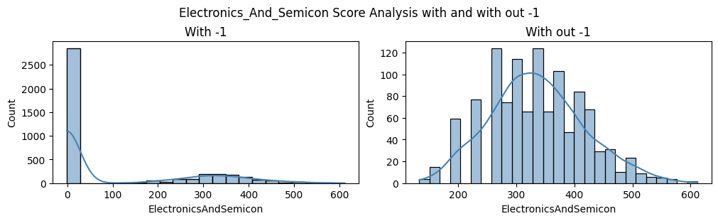

```python
    fig, axs = plt.subplots(1, 2, figsize=(10, 3), constrained_layout=True)
    fig.suptitle("Electronics_And_Semicon Score Analysis with and with out -1")

    axs[0].set_title("With -1")
    sns.histplot(data=df, x='ElectronicsAndSemicon', kde = True, ax=axs[0], color = 'steelblue')

    axs[1].set_title("With out -1")
    sns.histplot(data=es, x='ElectronicsAndSemicon', kde = True, ax=axs[1], color = 'steelblue')

    plt.show()
```

```python
cs = df[df['ComputerScience'] != -1]
```

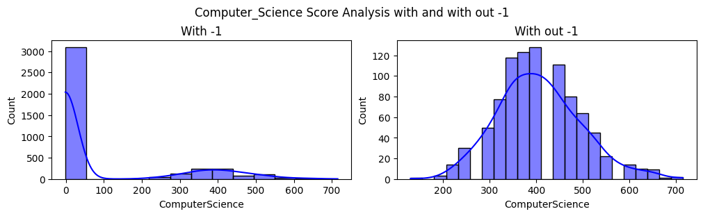

```python
    fig, axs = plt.subplots(1, 2, figsize=(10, 3), constrained_layout=True)
    fig.suptitle("Computer_Science Score Analysis with and with out -1")

    axs[0].set_title("With -1")
    sns.histplot(data=df, x='ComputerScience', kde = True, ax=axs[0], color = 'blue')

    axs[1].set_title("With out -1")
    sns.histplot(data=cs, x='ComputerScience', kde = True, ax=axs[1], color = 'blue')

    plt.show()
```

```python
en = df[df['MechanicalEngg'] != -1]
```

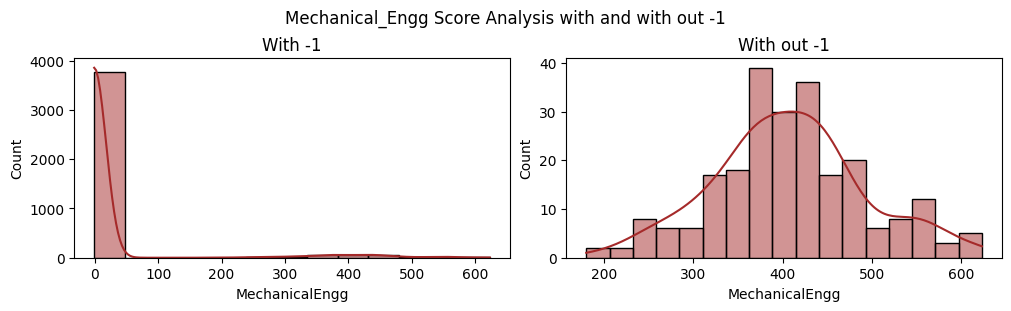

```python
    fig, axs = plt.subplots(1, 2, figsize=(10, 3), constrained_layout=True)
    fig.suptitle("Mechanical_Engg Score Analysis with and with out -1")

    axs[0].set_title("With -1")
    sns.histplot(data=df, x='MechanicalEngg', kde = True, ax=axs[0], color = 'brown')

    axs[1].set_title("With out -1")
    sns.histplot(data=en, x='MechanicalEngg', kde = True, ax=axs[1], color = 'brown')

    plt.show()
```

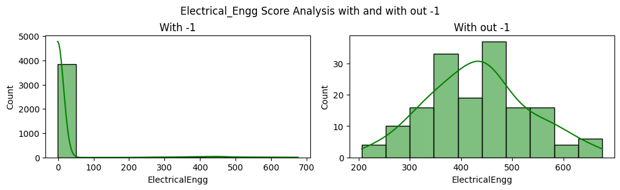

```python
    ee = df[df['ElectricalEngg'] != -1]

    fig, axs = plt.subplots(1, 2, figsize=(10, 3), constrained_layout=True)
    fig.suptitle("Electrical_Engg Score Analysis with and with out -1")

    axs[0].set_title("With -1")
    sns.histplot(data=df, x='ElectricalEngg', kde = True, ax=axs[0], color = 'green')

    axs[1].set_title("With out -1")
    sns.histplot(data=ee, x='ElectricalEngg', kde = True, ax=axs[1], color = 'green')

    plt.show()
```

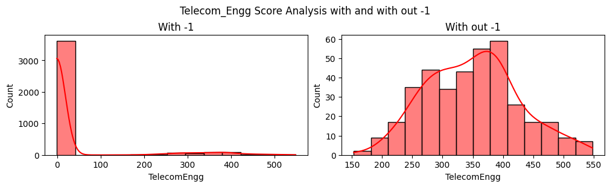

```python
    te = df[df['TelecomEngg'] != -1]

    fig, axs = plt.subplots(1, 2, figsize=(10, 3), constrained_layout=True)
    fig.suptitle("Telecom_Engg Score Analysis with and with out -1")

    axs[0].set_title("With -1")
    sns.histplot(data=df, x='TelecomEngg', kde = True, ax=axs[0], color = 'red')

    axs[1].set_title("With out -1")
    sns.histplot(data=te, x='TelecomEngg', kde = True, ax=axs[1], color = 'red')

    plt.show()
```

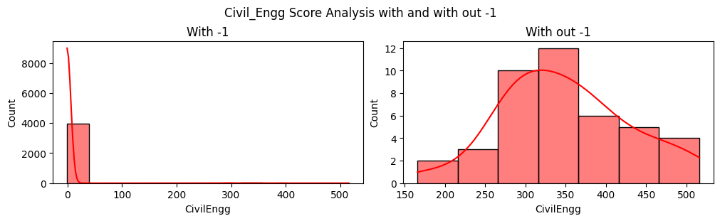

```python
    ce = df[df['CivilEngg'] != -1]

    fig, axs = plt.subplots(1, 2, figsize=(10, 3), constrained_layout=True)
    fig.suptitle("Civil_Engg Score Analysis with and with out -1")

    axs[0].set_title("With -1")
    sns.histplot(data=df, x='CivilEngg', kde = True, ax=axs[0], color = '#FF0000')

    axs[1].set_title("With out -1")
    sns.histplot(data=ce, x='CivilEngg', kde = True, ax=axs[1], color = '#FF0000')

    plt.show()
```

## Bi-Variate Analysis

#### Target Variable = Salary

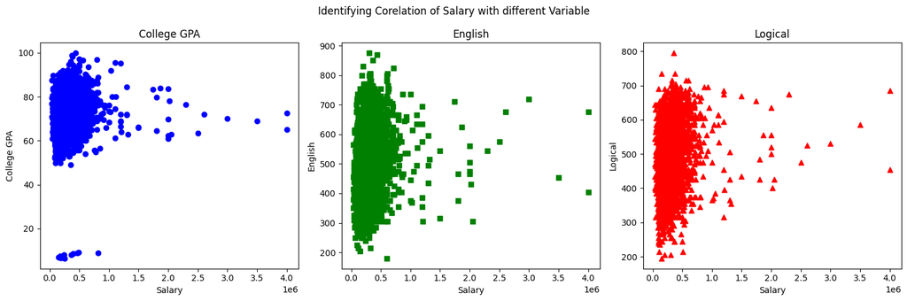

```python
    fig, axs = plt.subplots(1, 3, figsize=(15, 5))
    fig.suptitle("Identifying Corelation of Salary with different Variable")

    axs[0].scatter(df['Salary'], df['collegeGPA'], color='blue', marker='o')
    axs[0].set_title('College GPA')
    axs[0].set_xlabel('Salary')
    axs[0].set_ylabel('College GPA')

    axs[1].scatter(df['Salary'], df['English'], color='green', marker='s')
    axs[1].set_title('English')
    axs[1].set_xlabel('Salary')
    axs[1].set_ylabel('English')

    axs[2].scatter(df['Salary'], df['Logical'], color='red', marker='^')
    axs[2].set_title('Logical')
    axs[2].set_xlabel('Salary')
    axs[2].set_ylabel('Logical')

    plt.tight_layout()

    plt.show()
```

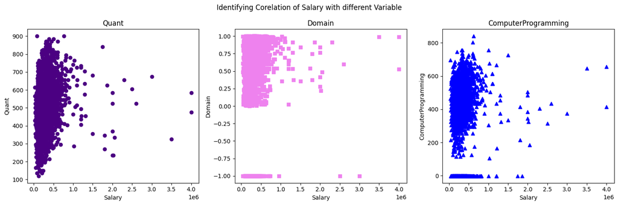

```python
    fig, axs = plt.subplots(1, 3, figsize=(15, 5))
    fig.suptitle("Identifying Corelation of Salary with different Variable")

    axs[0].scatter(df['Salary'], df['Quant'], color='indigo', marker='o')
    axs[0].set_title('Quant')
    axs[0].set_xlabel('Salary')
    axs[0].set_ylabel('Quant')

    axs[1].scatter(df['Salary'], df['Domain'], color='violet', marker='s')
    axs[1].set_title('Domain')
    axs[1].set_xlabel('Salary')
    axs[1].set_ylabel('Domain')

    axs[2].scatter(df['Salary'], df['ComputerProgramming'], color='blue', marker='^')
    axs[2].set_title('ComputerProgramming')
    axs[2].set_xlabel('Salary')
    axs[2].set_ylabel('ComputerProgramming')

    plt.tight_layout()

    plt.show()
```

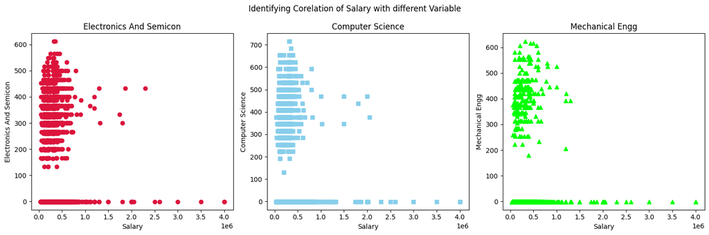

```python
    fig, axs = plt.subplots(1, 3, figsize=(15, 5))
    fig.suptitle("Identifying Corelation of Salary with different Variable")

    axs[0].scatter(df['Salary'], df['ElectronicsAndSemicon'], color='crimson', marker='o')
    axs[0].set_title('Electronics And Semicon')
    axs[0].set_xlabel('Salary')
    axs[0].set_ylabel('Electronics And Semicon')

    axs[1].scatter(df['Salary'], df['ComputerScience'], color='skyblue', marker='s')
    axs[1].set_title('Computer Science')
    axs[1].set_xlabel('Salary')
    axs[1].set_ylabel('Computer Science')

    axs[2].scatter(df['Salary'], df['MechanicalEngg'], color='lime', marker='^')
    axs[2].set_title('Mechanical Engg')
    axs[2].set_xlabel('Salary')
    axs[2].set_ylabel('Mechanical Engg')

    plt.tight_layout()

    plt.show()
```

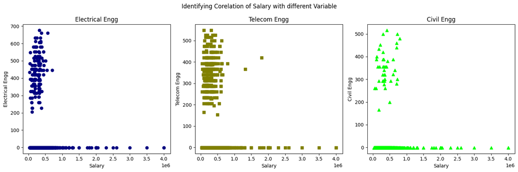

```python
    fig, axs = plt.subplots(1, 3, figsize=(15, 5))
    fig.suptitle("Identifying Corelation of Salary with different Variable")

    axs[0].scatter(df['Salary'], df['ElectricalEngg'], color='navy', marker='o')
    axs[0].set_title('Electrical Engg')
    axs[0].set_xlabel('Salary')
    axs[0].set_ylabel('Electrical Engg')

    axs[1].scatter(df['Salary'], df['TelecomEngg'], color='olive', marker='s')
    axs[1].set_title('Telecom Engg')
    axs[1].set_xlabel('Salary')
    axs[1].set_ylabel('Telecom Engg')

    axs[2].scatter(df['Salary'], df['CivilEngg'], color='lime', marker='^')
    axs[2].set_title('Civil Engg')
    axs[2].set_xlabel('Salary')
    axs[2].set_ylabel('Civil Engg')

    plt.tight_layout()

    plt.show()
```

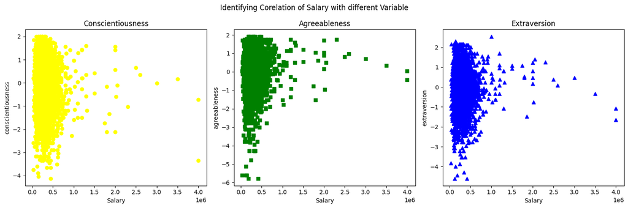

```python
    fig, axs = plt.subplots(1, 3, figsize=(15, 5))
    fig.suptitle("Identifying Corelation of Salary with different Variable")

    axs[0].scatter(df['Salary'], df['conscientiousness'], color='yellow', marker='o')
    axs[0].set_title('Conscientiousness')
    axs[0].set_xlabel('Salary')
    axs[0].set_ylabel('conscientiousness')

    axs[1].scatter(df['Salary'], df['agreeableness'], color='green', marker='s')
    axs[1].set_title('Agreeableness')
    axs[1].set_xlabel('Salary')
    axs[1].set_ylabel('agreeableness')

    axs[2].scatter(df['Salary'], df['extraversion'], color='blue', marker='^')
    axs[2].set_title('Extraversion')
    axs[2].set_xlabel('Salary')
    axs[2].set_ylabel('extraversion')

    plt.tight_layout()

    plt.show()
```

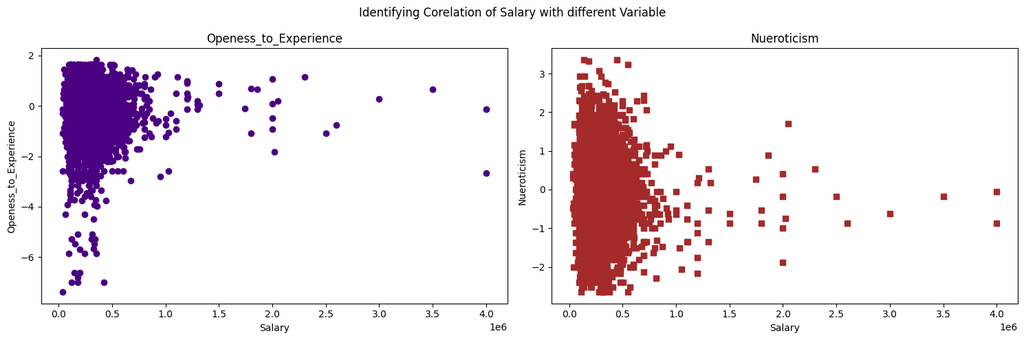

```python
    fig, axs = plt.subplots(1, 2, figsize=(15, 5))
    fig.suptitle("Identifying Corelation of Salary with different Variable")

    axs[0].scatter(df['Salary'], df['openess_to_experience'], color='indigo', marker='o')
    axs[0].set_title('Openess_to_Experience')
    axs[0].set_xlabel('Salary')
    axs[0].set_ylabel('Openess_to_Experience')

    axs[1].scatter(df['Salary'], df['nueroticism'], color='brown', marker='s')
    axs[1].set_title('Nueroticism')
    axs[1].set_xlabel('Salary')
    axs[1].set_ylabel('Nueroticism')


    plt.tight_layout()

    plt.show()
```

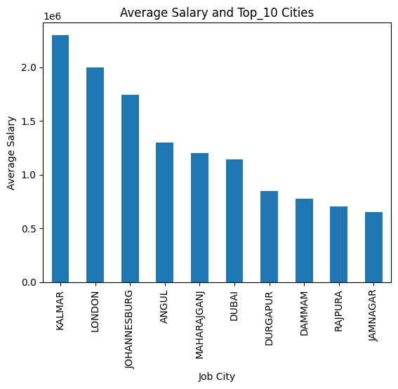

```python
    df.groupby('JobCity')['Salary'].mean().sort_values(ascending=False).head(10).plot(kind = 'bar')
    plt.ylabel("Average Salary")
    plt.xlabel("Job City")
    plt.title("Average Salary and Top_10 Cities")
    plt.show()
```

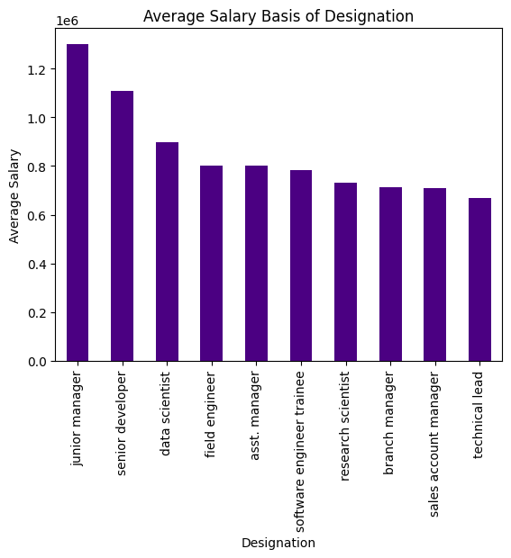

```python
    df.groupby('Designation')['Salary'].mean().sort_values(ascending=False).head(10).plot(kind = 'bar', color = 'indigo')
    plt.ylabel("Average Salary")
    plt.xlabel("Designation")
    plt.title("Average Salary Basis of Designation")
    plt.show()
```

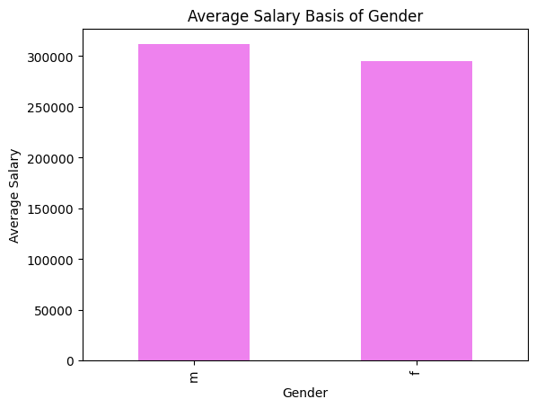

```python
    df.groupby('Gender')['Salary'].mean().sort_values(ascending=False).plot(kind = 'bar', color = 'violet')
    plt.ylabel("Average Salary")
    plt.xlabel("Gender")
    plt.title("Average Salary Basis of Gender")
    plt.show()
```

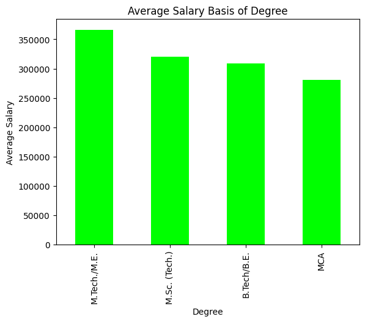

```python
    df.groupby('Degree')['Salary'].mean().sort_values(ascending=False).plot(kind = 'bar', color = 'lime')
    plt.ylabel("Average Salary")
    plt.xlabel("Degree")
    plt.title("Average Salary Basis of Degree")
    plt.show()
```

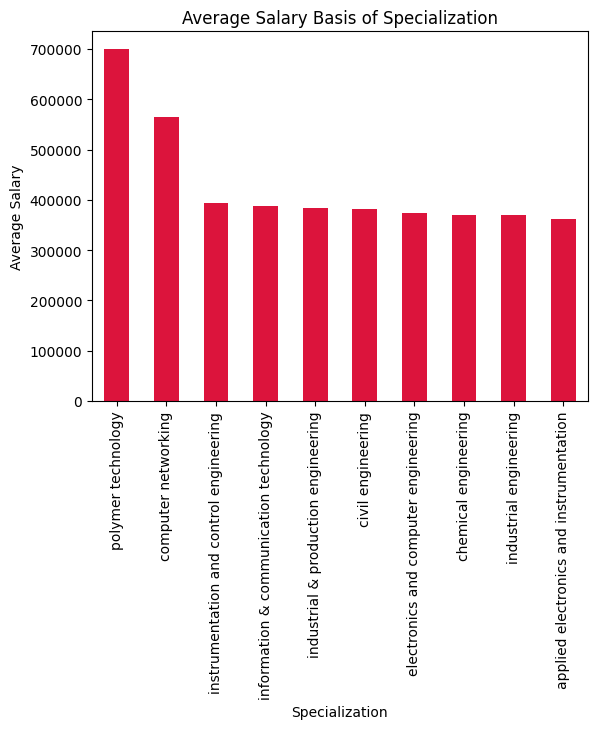

```python
    df.groupby('Specialization')['Salary'].mean().sort_values(ascending=False).head(10).plot(kind = 'bar', color = 'crimson')
    plt.ylabel("Average Salary")
    plt.xlabel("Specialization")
    plt.title("Average Salary Basis of Specialization")
    plt.show()
```

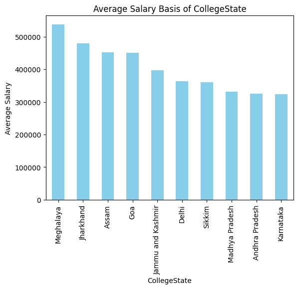

```python
    df.groupby('CollegeState')['Salary'].mean().sort_values(ascending=False).head(10).plot(kind = 'bar', color = 'skyblue')
    plt.ylabel("Average Salary")
    plt.xlabel("CollegeState")
    plt.title("Average Salary Basis of CollegeState")
    plt.show()
```

```python
object_col.columns
```

```
Index(['DOL', 'Designation', 'JobCity', 'Gender', '10board', '12board',
       'Degree', 'Specialization', 'CollegeState'],
      dtype='object')
```

```python
pd.crosstab(df['Specialization'].sort_values(ascending = False).head(10), df['Gender'],values='count', aggfunc='count')
```

| Gender Specialization | f | m |
| --- | --- | --- |
| other | NaN | 2.0 |
| polymer technology | NaN | 1.0 |
| power systems and automation | NaN | 1.0 |
| telecommunication engineering | 1.0 | 5.0 |

## Research Questions

### About:

**Times of India article dated Jan 18, 2019 states that “After doing your Computer Science Engineering if you take up jobs as a Programming Analyst, Software Engineer, Hardware Engineer and Associate Engineer you can earn up to 2.5-3 lakhs as a fresh graduate.” Test this claim with the data given to you.**

H0: Reject claim of average salary of fresh graduate.

H1: Failed to Reject claim of average salary of fresh graduate.

```python
    course = df[(df['Specialization'] == 'computer science and engineering') & (df['Salary'] > 0)]
    designation = course[course['Designation'].isin(['programming analyst', 'software engineer', 'hardware engineer', 'associate engineer'])]
    avg_sal = designation.groupby('Designation')['Salary'].mean()
```

```python
avg_sal.index[0], avg_sal.index[1]
```

```
('associate engineer', 'software engineer')
```

```python
 if avg_sal[0] >= 250000 and avg_sal[0] <= 400000:
    print("Failed to Reject claim of average salary of fresh graduate.")

else:
    print("Reject claim of average salary of fresh graduate.")

#Failed to Reject claim of average salary of fresh graduate.
```

```
Failed to Reject claim of average salary of fresh graduate.
```

```python
if avg_sal[1] >= 250000 and avg_sal[1] <= 400000:
    print("Failed to Reject claim of average salary of fresh graduate.")

else:
    print("Reject claim of average salary of fresh graduate.")
```

```
Failed to Reject claim of average salary of fresh graduate.
```

### Is there a relationship between gender and specialization? (i.e. Does the preference of Specialisation depend on the Gender?)

```python
    rel = pd.crosstab(df['Gender'], df['Specialization'])

    alpha = 0.05

    chi2, p, dof, expected = chi2_contingency(rel)

    print(f"Chi-squared statistic: {chi2}\n\n p-value: {p}\n\n Degrees of freedom: {dof}\n\n Expected frequencies table: {expected}\n\n")

    if p < alpha:
        print("Gender and Specialization has a relationship.")
    else:
        print("Gender and Specialization has no relationship.")
```

```
Chi-squared statistic: 101.26944511114863

 p-value: 3.205216802800075e-07

 Degrees of freedom: 40

 Expected frequencies table: [[7.18109055e-01 9.81415708e+00 1.19684842e+00 4.78739370e-01
  3.59054527e+00 2.39369685e-01 2.15432716e+00 6.94172086e+00
  2.39369685e-01 5.84062031e+01 2.39369685e-01 1.78569785e+02
  1.43621811e+00 2.39369685e-01 4.78739370e-01 1.96283142e+01
  2.89637319e+01 2.10884692e+02 1.44339920e+02 4.69164582e+01
  6.46298149e+00 4.54802401e+00 2.39369685e-01 2.39369685e-01
  2.39369685e+00 4.78739370e-01 4.78739370e-01 6.70235118e+00
  1.57983992e+02 4.78739370e+00 9.57478739e-01 2.39369685e-01
  2.39369685e-01 1.19684842e+00 4.81133067e+01 9.57478739e-01
  4.78739370e-01 3.11180590e+00 2.39369685e-01 2.39369685e-01
  1.43621811e+00]
 [2.28189095e+00 3.11858429e+01 3.80315158e+00 1.52126063e+00
  1.14094547e+01 7.60630315e-01 6.84567284e+00 2.20582791e+01
  7.60630315e-01 1.85593797e+02 7.60630315e-01 5.67430215e+02
  4.56378189e+00 7.60630315e-01 1.52126063e+00 6.23716858e+01
  9.20362681e+01 6.70115308e+02 4.58660080e+02 1.49083542e+02
  2.05370185e+01 1.44519760e+01 7.60630315e-01 7.60630315e-01
  7.60630315e+00 1.52126063e+00 1.52126063e+00 2.12976488e+01
  5.02016008e+02 1.52126063e+01 3.04252126e+00 7.60630315e-01
  7.60630315e-01 3.80315158e+00 1.52886693e+02 3.04252126e+00
  1.52126063e+00 9.88819410e+00 7.60630315e-01 7.60630315e-01
  4.56378189e+00]]


Gender and Specialization has a relationship.
```